# A Data Science Walkthrough Using Google Play Store App Data

Jim Kong

5/16/2020

# 1 Introduction

There’s no end to the amount of apps being developed, just as there’s no end to the potential profit from the mobile market. It doesn’t take much to understand why individual developers and companies alike would be interested in seeing their software grow in popularity, so we will attempt to investigate the factors that encourage a user to install one’s app using publicly-available data scraped from the Google Play Store by Lavanya Gupta. Once the provided data set is tidied and ready for study, we will perform some exploratory data analysis to discover attribute relationships before finally trying out predictive modeling.

# 2 Data Preparation

Before anything else, the data set must be made suitable for analysis. We will use *R* as our language of choice to accomplish this.

## 2.1 R Libraries

The only functions we will be utilizing more than once outside of base R are loaded here. One-off function calls will have their appropriate libraries (e.g., `caret`, `tree`) prepended to their invocations.

```r
library(tidyverse)  # For tidying data
library(ggplot2)    # For plotting data
```

## 2.2 Loading and Checking

Let’s take a look at the initial state of the data set immediately after downloading it.

```r
apps <- read.csv('googleplaystore.csv', stringsAsFactors=FALSE)
str(apps)
```

```
## 'data.frame':    10841 obs. of  13 variables:
##  $ App           : chr  "Photo Editor & Candy Camera & Grid & ScrapBook" "Coloring book moana" "U Launcher Lite – FREE Live Cool Themes, Hide Apps" "Sketch - Draw & Paint" ...
##  $ Category      : chr  "ART_AND_DESIGN" "ART_AND_DESIGN" "ART_AND_DESIGN" "ART_AND_DESIGN" ...
##  $ Rating        : num  4.1 3.9 4.7 4.5 4.3 4.4 3.8 4.1 4.4 4.7 ...
##  $ Reviews       : chr  "159" "967" "87510" "215644" ...
##  $ Size          : chr  "19M" "14M" "8.7M" "25M" ...
##  $ Installs      : chr  "10,000+" "500,000+" "5,000,000+" "50,000,000+" ...
##  $ Type          : chr  "Free" "Free" "Free" "Free" ...
##  $ Price         : chr  "0" "0" "0" "0" ...
##  $ Content.Rating: chr  "Everyone" "Everyone" "Everyone" "Teen" ...
##  $ Genres        : chr  "Art & Design" "Art & Design;Pretend Play" "Art & Design" "Art & Design" ...
##  $ Last.Updated  : chr  "January 7, 2018" "January 15, 2018" "August 1, 2018" "June 8, 2018" ...
##  $ Current.Ver   : chr  "1.0.0" "2.0.0" "1.2.4" "Varies with device" ...
##  $ Android.Ver   : chr  "4.0.3 and up" "4.0.3 and up" "4.0.3 and up" "4.2 and up" ...
```

```r
reviews <- read.csv('googleplaystore_user_reviews.csv', stringsAsFactors=FALSE)
str(reviews)
```

```
## 'data.frame':    64295 obs. of  5 variables:
##  $ App                   : chr  "10 Best Foods for You" "10 Best Foods for You" "10 Best Foods for You" "10 Best Foods for You" ...
##  $ Translated_Review     : chr  "I like eat delicious food. That's I'm cooking food myself, case \"10 Best Foods\" helps lot, also \"Best Before (Shelf Life)\"" "This help eating healthy exercise regular basis" "nan" "Works great especially going grocery store" ...
##  $ Sentiment             : chr  "Positive" "Positive" "nan" "Positive" ...
##  $ Sentiment_Polarity    : num  1 0.25 NaN 0.4 1 1 0.6 NaN 0 0 ...
##  $ Sentiment_Subjectivity: num  0.533 0.288 NaN 0.875 0.3 ...
```

## 2.3 Cleaning App Data

The preview of the `apps` data set shows that all of the attributes besides `Rating` have been loaded as `character` vectors, which is not exactly ideal. Closer inspection of the data reveals that the app called “Life Made WI-Fi Touchscreen Photo Frame” is missing values for `Category` and `Genres`, so we will revise that row in the data frame ourselves (missing attribute values were found by searching on the Play Store at the time of writing).

```r
apps[10473,] <- list("Life Made WI-Fi Touchscreen Photo Frame",  # App
                "LIFESTYLE",                                     # Category
                1.9,                                             # Rating
                "19.0",                                          # Reviews
                "3.0M",                                          # Size
                "1,000+",                                        # Installs
                "Free",                                          # Type
                "0",                                             # Price
                "Everyone",                                      # Content.Rating
                "Lifestyle",                                     # Genres
                "February 11, 2018",                             # Last.Updated
                "1.0.19",                                        # Current.Ver
                "4.0 and up")                                    # Android.Ver
```

Though this solves one problem, there still remains the issue that the columns’ types are not all suited to analysis. `App` and `Current.Ver` can stay as `character` vectors; let’s go through and modify the other attributes that need adjustment (note: more attributes than will be used later are edited for illustrative purposes).

### 2.3.1 Category

Since there are only so many possible values of `Category`, we will convert this column to be of type `factor`. No row is missing this attribute, so conversion is simple.

```r
apps <- mutate(apps, Category=as.factor(Category))
```

### 2.3.2 Rating

`Rating` is already a `numeric` type, so no operation is technically necessary. For consistency’s sake, however, we could convert the `NaN`s that appear into `NA`s.

```r
apps <- mutate(apps, Rating=ifelse(is.nan(Rating), NA, Rating))
```

### 2.3.3 Reviews

Another easy conversion—every row has a value for its `Reviews` column that directly translates into an integer, so we can convert this attribute to `numeric` without any other preparation.

```r
apps <- mutate(apps, Reviews=as.numeric(Reviews))
```

### 2.3.4 Size

```r
# Extract the numeric portion of the Size column
digits <- as.numeric(str_extract(apps$Size, '\\d+'))
# Extract the character portion and obtain its equivalent conversion factor
prefix <- toupper(str_extract(apps$Size, '[KkMm]'))
kb_factor <- c(1, 1000)[match(prefix, c('K', 'M'))]
# Replace the column
apps <- mutate(apps, Size=(digits * kb_factor))
```

### 2.3.5 Installs

The number of times an app is installed is not given as an exact integer, but as a lower bound. We will preserve this interpretation and remove any instances of “,” and “+” to be able to convert the `character`s to `numeric`s.

```r
apps <- mutate(apps, Installs=as.numeric(gsub('\\+', '', gsub(',', '', Installs))))
```

### 2.3.6 Type

Unforunately, not every observation in the data set has a `Type` that is either “Free” or “Paid”; fortunately, there is only one such deviant observation, which has a `Type` of “NaN” and can be manually replaced with “Free”, since its `Price` is 0 (if we were unluckier and had a large number of rows with “NaN” as their `Type`, a more generalized approach would be taken to infer the correct value). Once this single entry is corrected, we can convert the entire column to be of type `factor`.

```r
apps[9149, 7] <- "Free"
apps <- mutate(apps, Type=as.factor(Type))
```

### 2.3.7 Price

`Price` is represented as a `character` vector with dollar signs before any cost that isn’t 0. Those signs must be eliminated before conversion to a `numeric` type is possible.

```r
apps <- mutate(apps, Price=as.numeric(gsub('\\$', '', Price)))
```

### 2.3.8 Content Rating

`Content.Rating` has five enumerated values plus the “Unrated” value, which lends itself nicely to being a `factor`.

```r
apps <- mutate(apps, Content.Rating=factor(Content.Rating))
```

### 2.3.9 Genres

The problem with attempting to convert `Genres` to the `factor` type is that apps can be tagged with more than one genre. Luckily for us, the apps in this data set have at most two genres at once, so we will split the `Genres` attribute into two `factor` columns, where the second column can be `NA` if only one genre is provided.

```r
# Split column into two
apps <- separate(apps, Genres, c('Genre1', 'Genre2'), ';', fill='right')
# Rather than coerce directly, build factor manually so both columns can use the same levels including NA
apps <- mutate(apps, Genre1=factor(Genre1, levels=unique(Genre1), exclude=''))
apps <- mutate(apps, Genre2=factor(Genre2, levels=levels(Genre1)))
```

### 2.3.10 Last Updated

Since the dates are formatted consistently across every row, we will convert `Last.Updated` to the appropriately-named `Date` object type.

```r
apps <- mutate(apps, Last.Updated=as.Date(Last.Updated, format='%B %d, %Y'))
```

### 2.3.11 Android Version

There are 32 unique values used in the data set to represent the ranges of Android compatibility if “Varies with device” and “NaN” are excluded. After converting “NaN” to `NA`, the rest of the character vectors can be treated as `factor`s.

```r
apps <- mutate(apps, Android.Ver=ifelse(Android.Ver=="NaN", NA, Android.Ver))
apps <- mutate(apps, Android.Ver=factor(Android.Ver, levels=unique(Android.Ver), exclude=NA))
```

## 2.4 Cleaning Review Data

The text of the user reviews themselves are not particularly helpful to us; however, the data set is kind enough to provide additional values that *are* useful. Of these values, we will consider `Sentiment_Polarity` and `Sentiment_Subjectivity`. `Sentiment` will not be used because it can be inferred from the sign of `Sentiment_Polarity` and provides less information than its `numeric` counterpart. As far as data tidying goes, we need to prepare the desired columns for reporting in aggregate, so we’ll summarize `reviews` to create a new table that displays the arithmetic mean for each unique app.

```r
review_averages <- reviews %>%
  group_by(App) %>%
  summarize(Mean_Polarity=mean(Sentiment_Polarity, na.rm=TRUE), Mean_Subjectivity=mean(Sentiment_Subjectivity, na.rm=TRUE)) %>%
  mutate(Mean_Polarity=ifelse(is.nan(Mean_Polarity), NA, Mean_Polarity),
        Mean_Subjectivity=ifelse(is.nan(Mean_Subjectivity), NA, Mean_Subjectivity))
```

## 2.5 Putting the Data Together

The entities represented by the `reviews` table are, of course, user reviews of apps. That’s not what we’re interested in, though. We want to look at the apps themselves, so we will join the `review_averages` table (whose rows actually represent apps) with the `apps` table to produce a master data set that we will simply call `data`.

```r
data <- left_join(apps, review_averages, by='App')
```

We now have the complete data set we will be working with!

```r
str(data)
```

```
## 'data.frame':    10841 obs. of  16 variables:
##  $ App              : chr  "Photo Editor & Candy Camera & Grid & ScrapBook" "Coloring book moana" "U Launcher Lite – FREE Live Cool Themes, Hide Apps" "Sketch - Draw & Paint" ...
##  $ Category         : Factor w/ 33 levels "ART_AND_DESIGN",..: 1 1 1 1 1 1 1 1 1 1 ...
##  $ Rating           : num  4.1 3.9 4.7 4.5 4.3 4.4 3.8 4.1 4.4 4.7 ...
##  $ Reviews          : num  159 967 87510 215644 967 ...
##  $ Size             : num  19000 14000 8000 25000 2000 5000 19000 29000 33000 3000 ...
##  $ Installs         : num  1e+04 5e+05 5e+06 5e+07 1e+05 5e+04 5e+04 1e+06 1e+06 1e+04 ...
##  $ Type             : Factor w/ 2 levels "Free","Paid": 1 1 1 1 1 1 1 1 1 1 ...
##  $ Price            : num  0 0 0 0 0 0 0 0 0 0 ...
##  $ Content.Rating   : Factor w/ 6 levels "Adults only 18+",..: 2 2 2 5 2 2 2 2 2 2 ...
##  $ Genre1           : Factor w/ 48 levels "Art & Design",..: 1 1 1 1 1 1 1 1 1 1 ...
##  $ Genre2           : Factor w/ 48 levels "Art & Design",..: NA NA NA NA NA NA NA NA NA NA ...
##  $ Last.Updated     : Date, format: "2018-01-07" "2018-01-15" ...
##  $ Current.Ver      : chr  "1.0.0" "2.0.0" "1.2.4" "Varies with device" ...
##  $ Android.Ver      : Factor w/ 33 levels "4.0.3 and up",..: 1 1 1 2 3 4 1 2 5 1 ...
##  $ Mean_Polarity    : num  NA 0.153 NA NA NA ...
##  $ Mean_Subjectivity: num  NA 0.642 NA NA NA ...
```

# 3 Exploratory Data Analysis

With data tidying out of the way, it’s time to see if there are any notable relationships between the different attributes. One variable that a developer would probably be interested in is the number of times their app gets downloaded—i.e., how popular their software is. It’s not unreasonable to assume that most, if not all, of the attributes in our data set factor into an end user’s decision to tap the “Install” button on the Play Store, so to get started, let’s consider the impact of `Price`.

## 3.1 Price

Instinct says to check how an app’s `Price` affects its installation count using a basic scatterplot; however, given the size of our data set, it’s likely that we’ll run into issues with overplotting and end up with a hard-to-read plot. A better sense of the distribution of `Price` would be nice, so as a preliminary check we’ll observe quantiles.

```r
quantile(data$Price, probs=seq(0, 1, 0.1))
```

```
##   0%  10%  20%  30%  40%  50%  60%  70%  80%  90% 100%
##    0    0    0    0    0    0    0    0    0    0  400
```

It’s quite clear that the vast majority of the apps in our data set are free of charge. To keep things fair using the data we have, we’ll only consider free apps from this point forward and investigate the effect of attributes besides `Price`.

```r
data <- filter(data, Price==0)  # Filter out any apps with a cost of not $0.00
```

## 3.2 Installs (Transformed) vs. Rating

Let’s see if `Rating` has any correlation with `Installs` using a scatterplot, grouped by `Category`. For the sake of relationship-checking, and because the range of minimum installation counts is so expansive, we will transform our y-axis values onto a friendlier scale by taking the natural log of `Installs`.

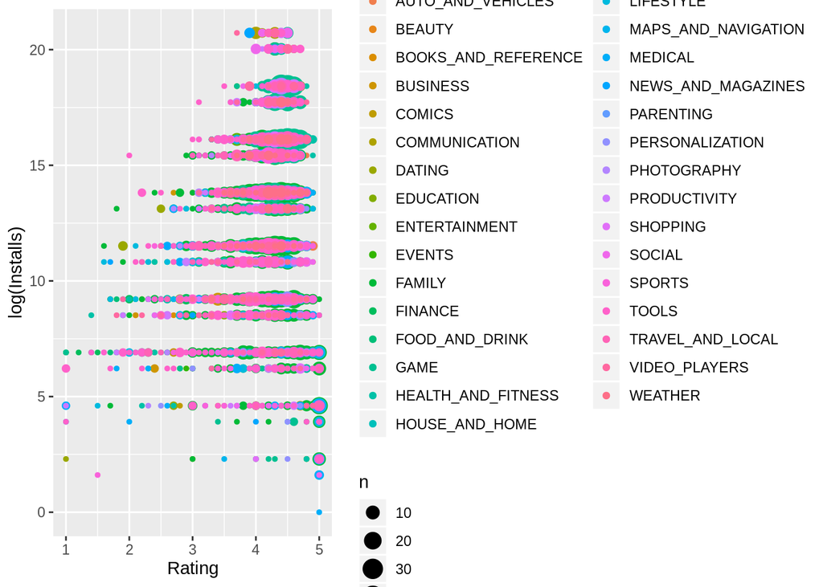

```r
data %>%
  filter(!is.na(Rating)) %>%
  ggplot(aes(x=Rating, y=log(Installs))) +
    geom_count(aes(color=Category))  # geom_count() deals with overlap better than geom_point()
```

It appears that highly-rated free apps have a wide range of potential users, whereas poorly-rated free apps tend to remain less popular. No single category of app stands out as different from this trend. We can quantitatively determine if the relationship between `log(Installs)` and `Rating` is approximately linear by performing a regression test.

```r
fit <- lm(log(Installs) ~ Rating, data=filter(data, !is.na(Rating)))
summary(fit)
```

```
##
## Call:
## lm(formula = log(Installs) ~ Rating, data = filter(data, !is.na(Rating)))
##
## Residuals:
##      Min       1Q   Median       3Q      Max
## -13.4106  -2.5891   0.8077   3.0096   8.6218
##
## Coefficients:
##             Estimate Std. Error t value Pr(>|t|)
## (Intercept)  8.37568    0.32695   25.62   <2e-16 ***
## Rating       1.00698    0.07753   12.99   <2e-16 ***
## ---
## Signif. codes:  0 '***' 0.001 '**' 0.01 '*' 0.05 '.' 0.1 ' ' 1
##
## Residual standard error: 3.713 on 8718 degrees of freedom
## Multiple R-squared:  0.01898,    Adjusted R-squared:  0.01887
## F-statistic: 168.7 on 1 and 8718 DF,  p-value: < 2.2e-16
```

Given the extremely small $p$-value for `Rating`, we can conclude that the slope of the line for `log(Installs)` vs. `Rating` differs from 0 and that this result is statistically significant—i.e., the two attributes are, with high probability, positively correlated.

## 3.3. Installs (Transformed) vs. Mean Polarity and Mean Subjectivity

Our impressions of an app (or any product, for that matter) are swayed by the voiced opinions of others, so it stands to reason that the average sentiment polarity—whether the average user review is positive or negative—may help predict an app’s popularity. Let’s verify this visually by plotting `Mean_Polarity` against `log(Installs)`.

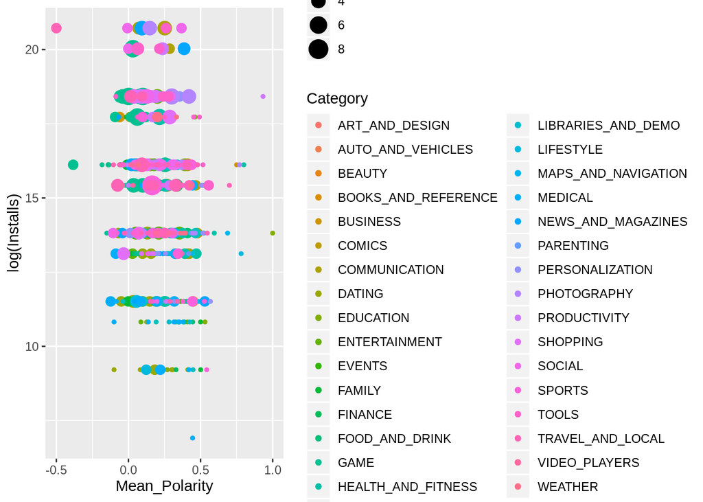

```r
data %>%
  filter(!is.na(Mean_Polarity)) %>%
  ggplot(aes(x=Mean_Polarity, y=log(Installs))) +
    geom_count(aes(color=Category))
```

The relationship between average sentiment polarity and transformed minimum installation count among free apps is not apparent: user reviews tend towards being positive no matter how popular an app is. To be sure of this intuition, we will again perform a regression test.

```r
fit <- lm(log(Installs) ~ Mean_Polarity, data=filter(data, !is.na(Mean_Polarity)))
summary(fit)
```

```
##
## Call:
## lm(formula = log(Installs) ~ Mean_Polarity, data = filter(data,
##     !is.na(Mean_Polarity)))
##
## Residuals:
##    Min     1Q Median     3Q    Max
## -7.312 -1.508  0.227  1.623  6.200
##
## Coefficients:
##               Estimate Std. Error t value Pr(>|t|)
## (Intercept)    15.9773     0.1044 153.104   <2e-16 ***
## Mean_Polarity  -3.9500     0.4298  -9.191   <2e-16 ***
## ---
## Signif. codes:  0 '***' 0.001 '**' 0.01 '*' 0.05 '.' 0.1 ' ' 1
##
## Residual standard error: 2.331 on 1212 degrees of freedom
## Multiple R-squared:  0.06515,    Adjusted R-squared:  0.06438
## F-statistic: 84.47 on 1 and 1212 DF,  p-value: < 2.2e-16
```

There’s high probability of a linear relationship after all, though perhaps not in the expected way, as the linear fit estimates a negative slope. This would mean that the more positive an app’s reviews lean, the fewer installations it probably has.

It’s also worth considering that views steeped in obvious subjectivity may not hold as much weight as those noting an app’s flaws and features dispassionately. Let’s try to take this into account mathematically by multiplying `Mean_Polarity` by $1 -$`Mean_Subjectivity` in our analysis.

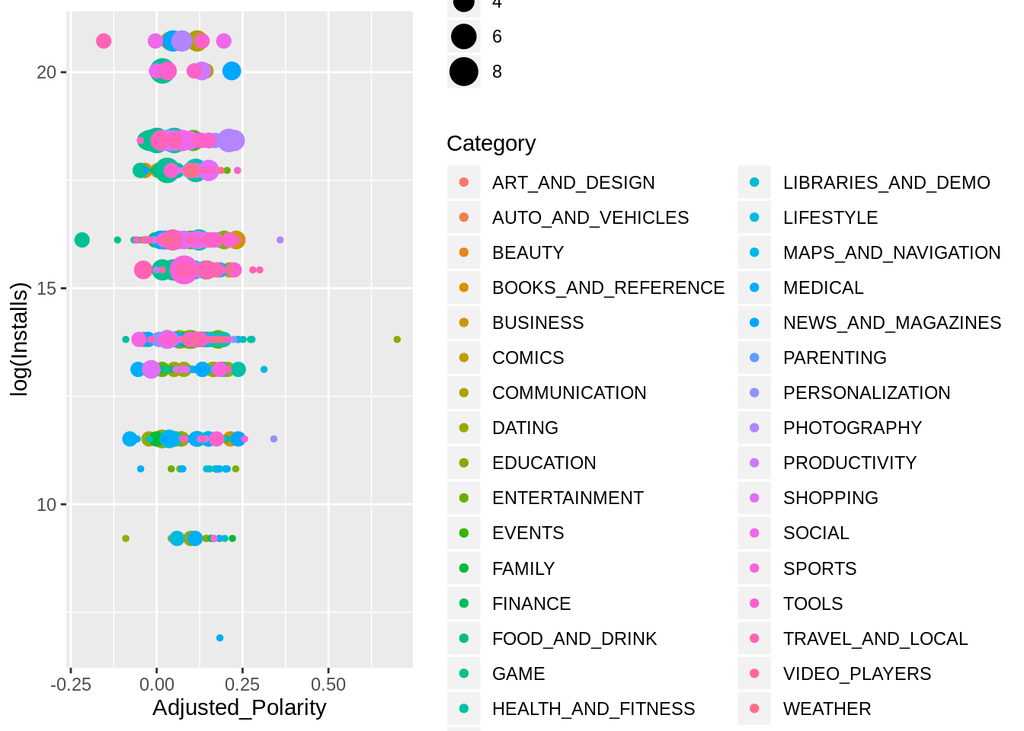

```r
adjusted_data <- data %>%
  filter(!is.na(Mean_Polarity) & !is.na(Mean_Subjectivity)) %>%
  mutate(Adjusted_Polarity=(Mean_Polarity * (1 - Mean_Subjectivity)))
ggplot(adjusted_data, aes(x=Adjusted_Polarity, y=log(Installs))) +
  geom_count(aes(color=Category))
```

```r
fit <- lm(log(Installs) ~ Adjusted_Polarity, data=adjusted_data)
summary(fit)
```

```
##
## Call:
## lm(formula = log(Installs) ~ Adjusted_Polarity, data = adjusted_data)
##
## Residuals:
##     Min      1Q  Median      3Q     Max
## -7.6023 -1.5210  0.2346  1.5278  6.3028
##
## Coefficients:
##                   Estimate Std. Error t value Pr(>|t|)
## (Intercept)        15.9598     0.1069 149.347   <2e-16 ***
## Adjusted_Polarity  -7.8830     0.9120  -8.644   <2e-16 ***
## ---
## Signif. codes:  0 '***' 0.001 '**' 0.01 '*' 0.05 '.' 0.1 ' ' 1
##
## Residual standard error: 2.34 on 1212 degrees of freedom
## Multiple R-squared:  0.05806,    Adjusted R-squared:  0.05729
## F-statistic: 74.71 on 1 and 1212 DF,  p-value: < 2.2e-16
```

As it turns out, the conclusions to be made are pretty much the same, with or without `Mean_Subjectivity` taken into account.

## 3.4 Installs vs. Content Rating

Checking the relationship between `Installs` and `Content.Rating` could provide insight into user demographics. To see how much each `Content.Rating` category contributes to the total `Installs` value, we’ll use a bar graph.

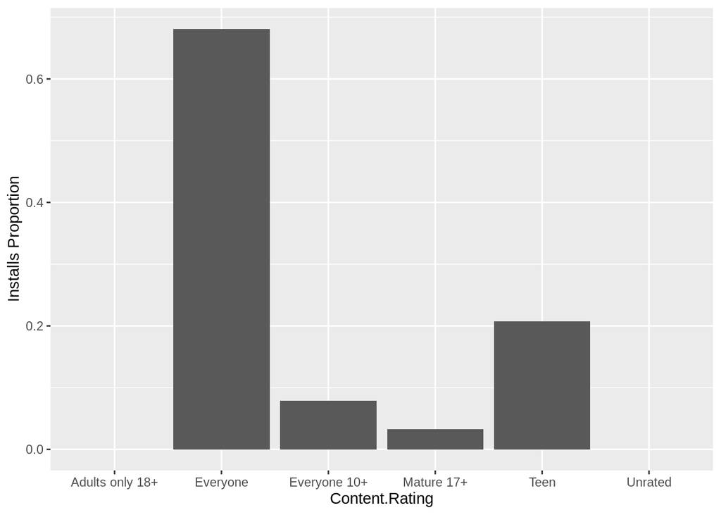

```r
Installs.Total <- sum(data$Installs)
data %>%
  group_by(Content.Rating) %>%
  summarize(Content.Rating.Total=sum(Installs)) %>%
  ggplot(aes(x=Content.Rating, y=(Content.Rating.Total / Installs.Total))) +
    geom_bar(stat='identity') +
    labs(y='Installs Proportion')
```

The majority of app downloads on the Play Store come from apps rated for everyone; meanwhile, apps that are not rated at all or are meant for adults only contribute a negligible amount to the overall installation count.

For illustration of distribution with each category, we’ll use a boxplot.

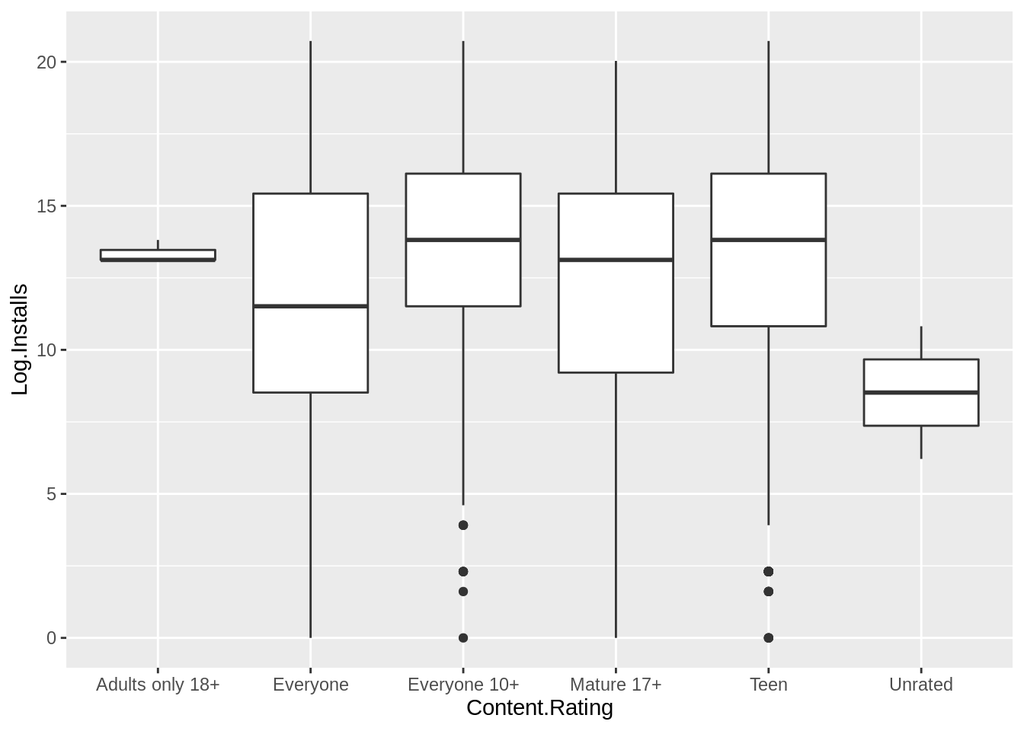

```r
data %>%
  mutate(Log.Installs=ifelse(Installs == 0, 0, log(Installs))) %>%
  ggplot(aes(x=Content.Rating, y=Log.Installs)) +
    geom_boxplot()
```

The categories that contribute a meaningful amount to the `Installs` total vary widely from app to app, which is to be expected. To conclude our exploratory analysis, we will test for a linear relationship between `Installs` and the categories of `Content.Rating`.

```r
adjusted_data <- data %>%
  mutate(Log_Installs=ifelse(Installs == 0, 0, log(Installs)))
fit <- lm(Log_Installs ~ Content.Rating, data=adjusted_data)
summary(fit)
```

```
##
## Call:
## lm(formula = Log_Installs ~ Content.Rating, data = adjusted_data)
##
## Residuals:
##     Min      1Q  Median      3Q     Max
## -13.951  -2.707   0.289   3.396   9.499
##
## Coefficients:
##                            Estimate Std. Error t value Pr(>|t|)
## (Intercept)                  13.353      2.555   5.227 1.76e-07 ***
## Content.RatingEveryone       -2.130      2.555  -0.833    0.405
## Content.RatingEveryone 10+    0.598      2.565   0.233    0.816
## Content.RatingMature 17+     -1.013      2.563  -0.395    0.693
## Content.RatingTeen           -0.631      2.558  -0.247    0.805
## Content.RatingUnrated        -4.836      4.040  -1.197    0.231
## ---
## Signif. codes:  0 '***' 0.001 '**' 0.01 '*' 0.05 '.' 0.1 ' ' 1
##
## Residual standard error: 4.425 on 10035 degrees of freedom
## Multiple R-squared:  0.02465,    Adjusted R-squared:  0.02416
## F-statistic: 50.72 on 5 and 10035 DF,  p-value: < 2.2e-16
```

The slopes shown in the regression summary do not significantly differ from the slope estimated when an app’s `Content.Rating` is “Adults only 18+”, and because the categories do not differ enough from each other, it would be best to exclude them from use in prediction.

# 4 Predictive Modeling

Although other attributes might plausibly contribute to prediction, we will focus on predicting `Installs` based on `Rating` as well as interaction between `Mean_Polarity` and `Mean_Subjectivity` using a linear model to reflect the data analyses above.

## 4.1 Distinguishing Training and Testing Data

The data used to train a machine learning model should not include the same observations we plan to evaluate the model’s performance with; therefore, we need to set aside a portion of the full data set exclusively for training. To ensure a large training set size, we will use *10-fold cross validation* as our evaluation method. We will also use the natural log of `Installs` as our variable of interest to align with our exploratory analyses.

## 4.2 Fitting and Evaluation

A few helper definitions for the upcoming testing:

```r
# Complete data set to be used for modeling
model_data <- data %>%
  select(Installs, Rating, Mean_Polarity, Mean_Subjectivity) %>%
  filter(!is.na(Rating) & !is.na(Mean_Polarity) & !is.na(Mean_Subjectivity)) %>%
  mutate(Log_Installs=ifelse(Installs == 0, 0, log(Installs)))

# Number of folds
k <- 10

# Create partitions
partitions <- caret::createFolds(model_data$Log_Installs, k=k)

# Define bin boundaries between Installs values
thresholds <- log(sort(unique(data$Installs))[-1])

# Return whether or not `a` and `b` belong to the same Installs bin
bin_match <- function(a, b, bin_thresholds) {
  for (i in 1:(length(bin_thresholds) - 1)) {
    if (a >= bin_thresholds[i] && a < bin_thresholds[i + 1]) {
      if (b >= bin_thresholds[i] && b < bin_thresholds[i + 1]) {
        return(TRUE)
      }
      return(FALSE)
    }
  }
  return(a >= last(bin_thresholds) && b >= last(bin_thresholds))
}
```

### 4.2.1 Linear Regression with Interaction

First we’ll test the effectiveness of *linear regression* under the assumption that `Mean_Polarity` and `Mean_Subjectivity` interact with each other.

```r
# Iterate over folds
linear_res <- lapply(seq_along(partitions),  function(i) {
  # Train model
  fit <- lm(Log_Installs ~ Rating + Mean_Polarity * Mean_Subjectivity, data=model_data[-partitions[[i]],])

  # Make predictions on the holdout set
  preds <- predict(fit, newdata=model_data[partitions[[i]],])

  # Compute true/false positive rates from the holdout set
  correct <- sum(ifelse(
    bin_match(preds, model_data$Log_Installs[partitions[[i]]], thresholds),
    1,
    0
  ))
  incorrect <- length(preds) - correct

  # Collect values for this fold
  data_frame(iteration=i, correct, incorrect)
})

# Combine values across all folds into a single data frame
do.call(rbind, linear_res)
```

```
## # A tibble: 10 x 3
##    iteration correct incorrect
##        <int>   <dbl>     <dbl>
##  1         1       0       121
##  2         2       1       121
##  3         3       0       121
##  4         4       1       120
##  5         5       0       121
##  6         6       0       121
##  7         7       0       121
##  8         8       0       121
##  9         9       0       122
## 10        10       0       122
```

The column labeled “correct” indicates the number of accurately-predicted `log(Installs)` estimates within a fold, whereas the “incorrect” column indicates the opposite. It’s pretty obvious without any further analysis that this model is an extremely poor predictor of `log(Installs)`.

### 4.2.2 Regression Tree

Since linear regression went so poorly, how about a new model? Here we will grow *regression trees* and perform the same 10-fold cross validation, with the only catch being that we will have to adjust our formula, since we cannot use interaction terms. Consequently, we’ll exclude `Mean_Subjectivity` and use `Mean_Polarity` as a standalone predictor.

```r
tree_res <- lapply(seq_along(partitions),  function(i) {
  fit <- tree::tree(Log_Installs ~ Rating + Mean_Polarity, data=model_data[-partitions[[i]],])

  preds <- predict(fit, newdata=model_data[partitions[[i]],])

  correct <- sum(ifelse(
    bin_match(preds, model_data$Log_Installs[partitions[[i]]], thresholds),
    1,
    0
  ))
  incorrect <- length(preds) - correct

  data_frame(iteration=i, correct, incorrect)
})

do.call(rbind, tree_res)
```

```
## # A tibble: 10 x 3
##    iteration correct incorrect
##        <int>   <dbl>     <dbl>
##  1         1       1       120
##  2         2       1       121
##  3         3       0       121
##  4         4       1       120
##  5         5       0       121
##  6         6       0       121
##  7         7       0       121
##  8         8       0       121
##  9         9       0       122
## 10        10       0       122
```

Unfortunately, this model is equally bad at predicting `log(Installs)`.

### 4.2.3 Linear Regression without Interaction

```r
linear_res_2 <- lapply(seq_along(partitions),  function(i) {
  fit <- lm(Log_Installs ~ Rating + Mean_Polarity, data=model_data[-partitions[[i]],])

  preds <- predict(fit, newdata=model_data[partitions[[i]],])

  correct <- sum(ifelse(
    bin_match(preds, model_data$Log_Installs[partitions[[i]]], thresholds),
    1,
    0
  ))
  incorrect <- length(preds) - correct

  data_frame(iteration=i, correct, incorrect)
})

do.call(rbind, linear_res)
```

```
## # A tibble: 10 x 3
##    iteration correct incorrect
##        <int>   <dbl>     <dbl>
##  1         1       0       121
##  2         2       1       121
##  3         3       0       121
##  4         4       1       120
##  5         5       0       121
##  6         6       0       121
##  7         7       0       121
##  8         8       0       121
##  9         9       0       122
## 10        10       0       122
```

# 5 Conclusions

We took a publicly-available data set on Google Play Store apps and user reviews and prepared it for analysis by editing an incorrectly-entered row, standardizing units, and changing column types. We focused our project by eliminating paid apps from analysis and transformed minimum installation count to use a more suitable scale. We visually examined the relationships between installations and attributes such as rating, app category, and review sentiment. We confirmed the existence of such relationships through tests of slope using the built-in null hypothesis of linear slope coefficient being 0. Finally, we trained linear regression and regression tree models based on the assumption of a linear relationship between installations and rating + sentiment but found it to be an inaccurate predictor.

In truth, the assumption of linearity was probably poorly founded, which warrants future investigation into the true nature of installation count’s relationship with its app store data (i.e., seeing that it is, in fact, not linear). In addition to exploring other relationships, there is always the avenue of trying out different modeling methods such as random forests.

Getting the chance for insight into the Play Store and the wider population of apps I never even knew existed was both a fun and informative experience. Professionals are almost certainly performing similar analyses of apps for development/marketing purposes already, so practicing now can only be beneficial for any future work or research.

# 6 Additional Reading

- Google Play Store Data: https://www.kaggle.com/lava18/google-play-store-apps
- `ggplot2` tutorial: http://tutorials.iq.harvard.edu/R/Rgraphics/Rgraphics.html
- Linear regression in R tutorial: https://www.r-bloggers.com/simple-linear-regression-2/
- Notes on model evaluation: https://www.hcbravo.org/IntroDataSci/bookdown-notes/model-selection-and-evaluation.html